# Introduction

Project Overview We applied unsupervised learning to a social‑media engagement dataset—likes, shares, comments and reaction emojis—without any predefined labels.

## Methodology

Data Preparation: Cleaned, imputed and scaled all metrics.

Dimensionality Reduction: Used PCA to extract the most informative features.

Interpretation: Profiled each cluster to see which content types drive the most “loves,” comments and shares.

```python
########################################
# importing packages
########################################
import numpy                 as np  # mathematical essentials
import pandas                as pd  # data science essentials
import matplotlib.pyplot     as plt # fundamental data visualization
import seaborn               as sns # enhanced visualizations

# packages for unsupervised learning
from sklearn.preprocessing   import StandardScaler, PowerTransformer # standard scaler and power transformer
from sklearn.decomposition   import PCA                 # pca
from scipy.cluster.hierarchy import dendrogram, linkage # dendrograms
from sklearn.cluster         import KMeans              # k-means clustering
import scipy.cluster.hierarchy as sch

from sklearn.model_selection import train_test_split        # train-test split
from sklearn.metrics import roc_auc_score, accuracy_score, confusion_matrix # results analysis
from sklearn.linear_model import LogisticRegression # logistic regression
from sklearn.metrics import roc_auc_score # auc score
import sklearn.linear_model




# setting print options
pd.set_option('display.max_rows', 500)
pd.set_option('display.max_columns', 500)
pd.set_option('display.width', 1000)
pd.set_option('display.max_colwidth', 100)
```

```python
# Importing the data
data = pd.read_excel('/Users/himanshu/HULT/BC III/Facebook_Live_Data.xlsx')

data.head()
```

|  | status_id | status_type | time_published | num_comments | num_shares | num_likes | num_loves | num_wows | num_hahas | num_sads | num_angrys |
| --- | --- | --- | --- | --- | --- | --- | --- | --- | --- | --- | --- |
| 0 | 1 | photo | 2017-09-27 02:58:00 | 7 | 0 | 14 | 0 | 0 | 0 | 0 | 0 |
| 1 | 2 | photo | 2017-09-27 03:42:00 | 3 | 0 | 12 | 0 | 0 | 0 | 0 | 0 |
| 2 | 3 | photo | 2017-09-27 03:54:00 | 17 | 3 | 19 | 0 | 0 | 0 | 0 | 0 |
| 3 | 4 | photo | 2017-09-27 08:54:00 | 39 | 0 | 24 | 0 | 0 | 0 | 0 | 0 |
| 4 | 5 | photo | 2017-09-28 01:50:00 | 17 | 0 | 31 | 0 | 0 | 0 | 0 | 0 |

# Descriptive Analysis

```python
# check for missing values and info
data.info(verbose=True)
```

```
<class 'pandas.core.frame.DataFrame'>
RangeIndex: 2362 entries, 0 to 2361
Data columns (total 11 columns):
 #   Column          Non-Null Count  Dtype
---  ------          --------------  -----
 0   status_id       2362 non-null   int64
 1   status_type     2362 non-null   object
 2   time_published  2362 non-null   datetime64[ns]
 3   num_comments    2362 non-null   int64
 4   num_shares      2362 non-null   int64
 5   num_likes       2362 non-null   int64
 6   num_loves       2362 non-null   int64
 7   num_wows        2362 non-null   int64
 8   num_hahas       2362 non-null   int64
 9   num_sads        2362 non-null   int64
 10  num_angrys      2362 non-null   int64
dtypes: datetime64[ns](1), int64(9), object(1)
memory usage: 203.1+ KB
```

```python
# check values in the status_type column
data["status_type"].value_counts()
```

```
status_type
photo    1313
video     720
text      329
Name: count, dtype: int64
```

```python
# Analyzing full dataset with only numeric features of interest
data.iloc[:, 3:].describe().round(decimals=2)
```

|  | num_comments | num_shares | num_likes | num_loves | num_wows | num_hahas | num_sads | num_angrys |
| --- | --- | --- | --- | --- | --- | --- | --- | --- |
| count | 2362.00 | 2362.00 | 2362.00 | 2362.00 | 2362.00 | 2362.00 | 2362.00 | 2362.00 |
| mean | 231.59 | 39.54 | 236.27 | 12.23 | 1.27 | 0.72 | 0.28 | 0.12 |
| std | 851.52 | 123.70 | 487.42 | 40.85 | 8.84 | 4.11 | 1.86 | 0.89 |
| min | 0.00 | 0.00 | 0.00 | 0.00 | 0.00 | 0.00 | 0.00 | 0.00 |
| 25% | 0.00 | 0.00 | 17.00 | 0.00 | 0.00 | 0.00 | 0.00 | 0.00 |
| 50% | 4.00 | 0.00 | 53.00 | 0.00 | 0.00 | 0.00 | 0.00 | 0.00 |
| 75% | 24.00 | 3.00 | 177.00 | 2.00 | 0.00 | 0.00 | 0.00 | 0.00 |
| max | 10960.00 | 1260.00 | 4241.00 | 421.00 | 278.00 | 102.00 | 46.00 | 31.00 |

```python
# Descriptive statistics for engagement metrics
engagement_columns = ['num_comments', 'num_shares', 'num_likes', 'num_loves', 'num_wows', 'num_hahas', 'num_sads', 'num_angrys']
engagement_stats = data[engagement_columns].describe()

# Status type distribution
status_type_distribution = data['status_type'].value_counts()

# Display results
engagement_stats, status_type_distribution
```

```
(       num_comments   num_shares    num_likes    num_loves     num_wows    num_hahas     num_sads   num_angrys
 count   2362.000000  2362.000000  2362.000000  2362.000000  2362.000000  2362.000000  2362.000000  2362.000000
 mean     231.592718    39.535986   236.273920    12.229043     1.273074     0.724386     0.275614     0.118544
 std      851.523708   123.695257   487.423379    40.849986     8.837391     4.106254     1.864487     0.894902
 min        0.000000     0.000000     0.000000     0.000000     0.000000     0.000000     0.000000     0.000000
 25%        0.000000     0.000000    17.000000     0.000000     0.000000     0.000000     0.000000     0.000000
 50%        4.000000     0.000000    53.000000     0.000000     0.000000     0.000000     0.000000     0.000000
 75%       24.000000     3.000000   177.000000     2.000000     0.000000     0.000000     0.000000     0.000000
 max    10960.000000  1260.000000  4241.000000   421.000000   278.000000   102.000000    46.000000    31.000000,
 status_type
 photo    1313
 video     720
 text      329
 Name: count, dtype: int64)
```

# Principal Component Analysis

```python
# Select relevant engagement metrics for PCA
pca_columns = ['num_comments', 'num_shares', 'num_likes', 'num_loves', 'num_wows', 'num_hahas', 'num_sads', 'num_angrys']
data_pca = data[pca_columns]
```

### Scaling

```python
# Standardize the data
scaler = StandardScaler()
data_scaled = scaler.fit_transform(data_pca)

# Perform PCA
pca = PCA()
pca.fit(data_scaled)
```

```
PCA()
```

### Correlation

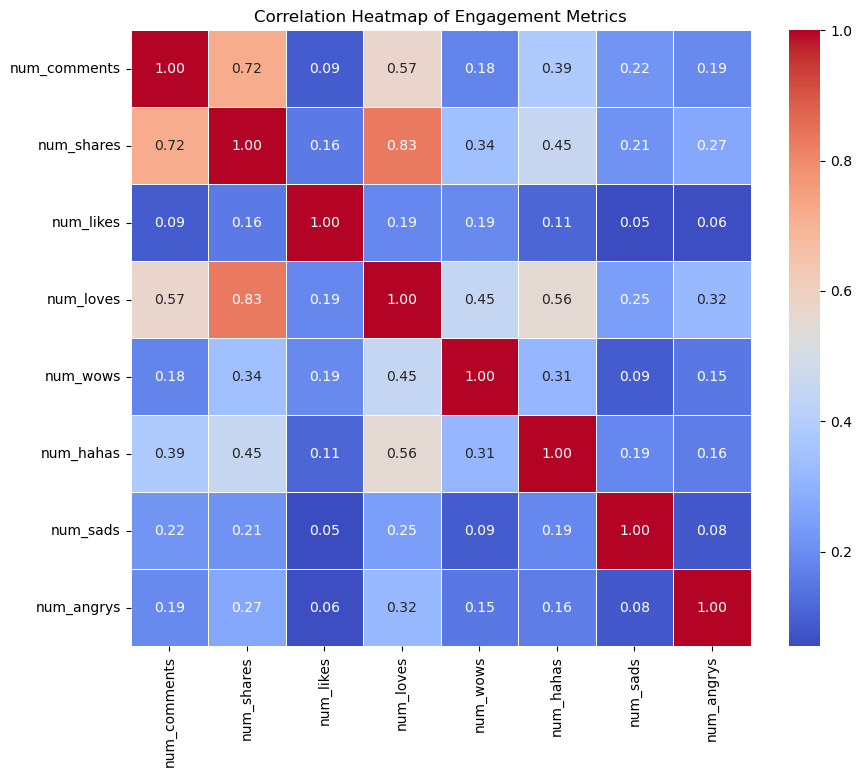

```python
# Calculate the correlation matrix for the engagement metrics
correlation_matrix = data[pca_columns].corr()

# Plot the correlation heatmap
plt.figure(figsize=(10, 8))
sns.heatmap(correlation_matrix, annot=True, cmap='coolwarm', fmt='.2f', cbar=True, linewidths=0.5)
plt.title('Correlation Heatmap of Engagement Metrics')
plt.show()
```

## Analysis of Engagement Metrics: Correlation Heatmap

num_comments and num_shares show a strong positive correlation (0.72), indicating that posts with more comments tend to have more shares.

num_shares and num_loves are highly correlated (0.83), suggesting that posts that are shared more frequently also tend to receive more love reactions.

num_likes has a low correlation with most other metrics, especially num_comments (0.09) and num_shares (0.16), implying that likes and comments/shares do not follow a direct relationship.

num_wows shows moderate positive correlation with num_loves (0.45) and num_hahas (0.31), suggesting that posts with more "wow" reactions tend to receive positive reactions (loves and laughs).

num_sads and num_angrys have weak correlations with other metrics, indicating that negative reactions (sads, angrys) occur less consistently across posts with high positive engagement.

Weak correlations across several metrics (like num_hahas, num_sads, and num_angrys) suggest that these metrics are not strongly linked to other types of engagement, and thus, the audience reaction to humor or negative emotions is less predictable.

### Scree Plot

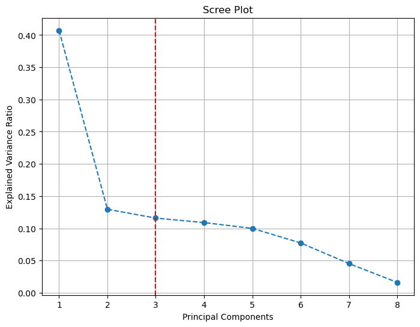

```
array([0.40719923, 0.12957994, 0.11587625, 0.10888031, 0.09991824,
       0.0772821 , 0.04528171, 0.01598221])
```

```python
# Explained variance ratio
explained_variance = pca.explained_variance_ratio_

# Scree plot to determine how many principal components to retain
plt.figure(figsize=(8, 6))
plt.plot(range(1, len(explained_variance) + 1), explained_variance, marker='o', linestyle='--')
plt.axvline(x=3, color='r', linestyle='--')  # Example of cutoff at 3 components
plt.title('Scree Plot')
plt.xlabel('Principal Components')
plt.ylabel('Explained Variance Ratio')
plt.grid(True)
plt.show()

# Explained variance values
explained_variance
```

## Insights from Scree Plot

Gradual Decline: After the first component, the explained variance decreases gradually, indicating that the subsequent components contribute less to explaining the variance in the data. This is common in many datasets, where a small number of components capture the majority of the variance.

Choosing Components: The vertical red line at Component 3 suggests that 3 principal components explain the majority of the variance. Based on the plot, it's clear that after the first three components, the additional components have diminishing contributions to the explained variance.

Variance Ratios: The explained variance ratios are printed below the plot, with the first component explaining 40.7% of the variance, the second explaining 12.9%, and the third explaining 11.6%. The remaining components each explain progressively smaller portions of the variance.

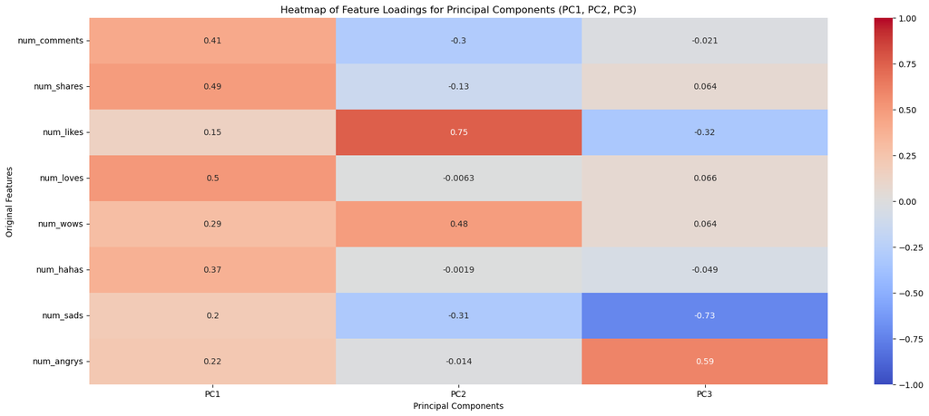

```python
# Factor loadings: correlations between original features and principal components
factor_loadings = pca.components_.T

# Create a dataframe for the factor loadings
factor_loadings_df = pd.DataFrame(factor_loadings, columns=[f'PC{i+1}' for i in range(len(factor_loadings))], index=pca_columns)

# Heatmap for the factor loadings of the first three principal components
plt.figure(figsize=(20, 8))
sns.heatmap(factor_loadings_df.iloc[:, :3], annot=True, cmap='coolwarm', center=0, vmin=-1, vmax=1)
plt.title('Heatmap of Feature Loadings for Principal Components (PC1, PC2, PC3)')
plt.xlabel('Principal Components')
plt.ylabel('Original Features')
plt.show()
```

## Analysis of Feature Loadings for Principal Components (PC1, PC2, PC3)

PC3: Strongly influenced by anger (0.59) and sads (-0.73), reflecting negative engagement. This component highlights how negative reactions like anger and sadness define a post’s engagement.

```python
# Renaming the first three principal components while leaving other columns as is
factor_loadings_df.columns = ['Engagement', 'Emotion', 'Controversy', 'PC4', 'PC5', 'PC6', 'PC7', 'PC8']

# Display only the columns for 'Engagement', 'Emotion', and 'Controversy'
factor_loadings_df[['Engagement', 'Emotion', 'Controversy']]
```

|  | Engagement | Emotion | Controversy |
| --- | --- | --- | --- |
| num_comments | 0.414479 | -0.296714 | -0.021164 |
| num_shares | 0.491360 | -0.125686 | 0.063631 |
| num_likes | 0.146640 | 0.754192 | -0.323463 |
| num_loves | 0.501665 | -0.006288 | 0.065926 |
| num_wows | 0.293736 | 0.481622 | 0.063904 |
| num_hahas | 0.373088 | -0.001897 | -0.048747 |
| num_sads | 0.195328 | -0.308462 | -0.725417 |
| num_angrys | 0.223548 | -0.014370 | 0.594844 |

```python
# Extracting the first three principal components
pca_data = pca.transform(data_scaled)[:, :3]

# Creating a DataFrame for the first three principal components
pca_df = pd.DataFrame(pca_data, columns=['Engagement', 'Emotion', 'Controversy'])

# Display the new DataFrame
pca_df.head()
```

|  | Engagement | Emotion | Controversy |
| --- | --- | --- | --- |
| 0 | -0.650177 | -0.245207 | 0.140874 |
| 1 | -0.652726 | -0.246908 | 0.142301 |
| 2 | -0.631884 | -0.244003 | 0.138850 |
| 3 | -0.631588 | -0.240884 | 0.133441 |
| 4 | -0.640193 | -0.222383 | 0.129341 |

# Clustering

```python
# Calculate variance before scaling
variance_pre_scaling = pca_df.var()

# Apply standard scaling (since the data is already in PCA format, it should be standardized already)
scaler = StandardScaler()
pca_df_scaled = scaler.fit_transform(pca_df)

# Convert the scaled data back to a DataFrame
pca_df_scaled = pd.DataFrame(pca_df_scaled, columns=['Engagement', 'Emotion', 'Controversy'])

# Calculate variance after scaling
variance_post_scaling = pca_df_scaled.var()

# Display the variances before and after scaling
variance_pre_scaling, variance_post_scaling
```

```
(Engagement     3.258974
 Emotion        1.037079
 Controversy    0.927403
 dtype: float64,
 Engagement     1.000424
 Emotion        1.000424
 Controversy    1.000424
 dtype: float64)
```

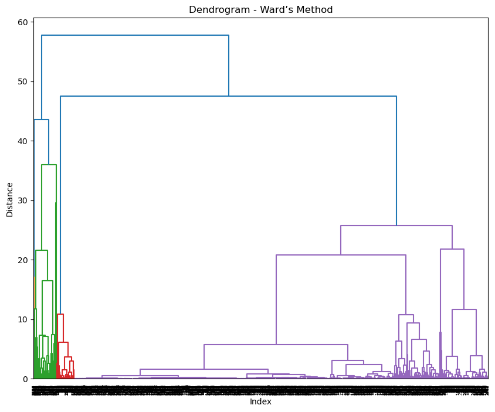

```python
# Perform hierarchical clustering using ward distance
linked = sch.linkage(pca_df_scaled, method='ward')

# Plot the dendrogram
plt.figure(figsize=(10, 8))
sch.dendrogram(linked)
plt.title('Dendrogram - Ward’s Method')
plt.xlabel('Index')
plt.ylabel('Distance')
plt.show()
```

## Interpretation

Cluster Formation:

The dendrogram illustrates how data points are grouped into clusters based on Ward's method, with the distance representing dissimilarity between clusters. Larger distances show that clusters are more distinct from each other.

Cluster Merging:

At the start, individual data points or small clusters are separated. As we move up the plot, these smaller clusters start merging into larger ones, showing how clusters with similar characteristics combine.

Optimal Clustering Point:

The large gap between clusters at distance ~30 suggests a point where the tree can be "cut" to define the ideal number of clusters. This gap is key in deciding the best number of clusters to form, as large gaps represent clusters that are very distinct from one another.

Key Insight:

Ward’s method ensures that the clusters formed are as compact as possible, reducing internal variance. The point at which the dendrogram is cut helps to determine how many clusters make sense for the analysis, focusing on similarity within each cluster.

```python
# Define the number of clusters based on the dendrogram (let's say we choose 4 clusters)
from scipy.cluster.hierarchy import fcluster

# Apply the cut-off to assign cluster labels
num_clusters = 3
cluster_labels = fcluster(linked, num_clusters, criterion='maxclust')

# Add the cluster labels to the pca_df_scaled DataFrame
pca_df_scaled['Cluster'] = cluster_labels

# Round the values to 2 decimal places
pca_df_scaled = pca_df_scaled.round(2)

# Display the DataFrame with cluster labels
pca_df_scaled.head()
```

|  | Engagement | Emotion | Controversy | Cluster |
| --- | --- | --- | --- | --- |
| 0 | -0.36 | -0.24 | 0.15 | 3 |
| 1 | -0.36 | -0.24 | 0.15 | 3 |
| 2 | -0.35 | -0.24 | 0.14 | 3 |
| 3 | -0.35 | -0.24 | 0.14 | 3 |
| 4 | -0.35 | -0.22 | 0.13 | 3 |

```python
# Group by 'Cluster' and calculate the mean for Engagement, Emotion, and Controversy
cluster_centers = pca_df_scaled.groupby('Cluster')[['Engagement', 'Emotion', 'Controversy']].mean()

# Display the result
cluster_centers
```

| Cluster | Engagement | Emotion | Controversy |
| --- | --- | --- | --- |
| 1 | 3.530410 | -0.699508 | 0.147131 |
| 2 | 0.149333 | 3.235333 | -1.316000 |
| 3 | -0.206060 | -0.095865 | 0.046753 |

```python
# Add the 'status_type' column from the original dataset to the new factorized DataFrame
factorized_df = pca_df_scaled[['Engagement', 'Emotion', 'Controversy']].copy()
factorized_df['status_type'] = data['status_type']

# Display the updated DataFrame
factorized_df.head()
```

|  | Engagement | Emotion | Controversy | status_type |
| --- | --- | --- | --- | --- |
| 0 | -0.36 | -0.24 | 0.15 | photo |
| 1 | -0.36 | -0.24 | 0.15 | photo |
| 2 | -0.35 | -0.24 | 0.14 | photo |
| 3 | -0.35 | -0.24 | 0.14 | photo |
| 4 | -0.35 | -0.22 | 0.13 | photo |

```python
# Ensure the 'Cluster' column is in the factorized_df
factorized_df['Cluster'] = pca_df_scaled['Cluster']

# Group by 'Cluster' and calculate the required statistics
cluster_summary = factorized_df.groupby('Cluster').agg(
    proportion=('Cluster', 'size'),
    Engagement=('Engagement', 'mean'),
    Emotion=('Emotion', 'mean'),
    Controversy=('Controversy', 'mean'),
    status_type_distribution=('status_type', lambda x: x.value_counts().to_dict())
)

# Calculate the proportion of observations in each cluster
total_observations = len(factorized_df)
cluster_summary['proportion'] = cluster_summary['proportion'] / total_observations

# Display the summary
cluster_summary
```

| Cluster | proportion | Engagement | Emotion | Controversy | status_type_distribution |
| --- | --- | --- | --- | --- | --- |
| 1 | 0.051651 | 3.530410 | -0.699508 | 0.147131 | {'video': 115, 'photo': 7} |
| 2 | 0.038103 | 0.149333 | 3.235333 | -1.316000 | {'photo': 43, 'text': 30, 'video': 17} |
| 3 | 0.910246 | -0.206060 | -0.095865 | 0.046753 | {'photo': 1263, 'video': 588, 'text': 299} |

# Logistic Regression

```python
# selecting x-data scaled
original_x_data = data_scaled

# selecting x-data pca
pc_x_data = pca_df

# selecting x-data clusters
cluster_x_data = pca_df_scaled

data['status_type'] = (data['status_type'] == 'video').astype(int)

# selecting y-data
y_data = data["status_type"]
```

```
AUC:      0.7897697393133498
Accuracy: 0.8222849083215797
```

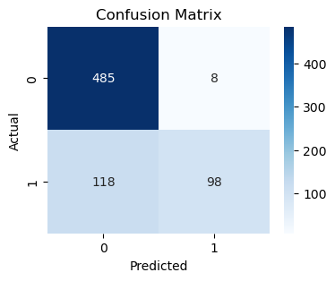

```
Train-Test Gap: 0.009
Test AUC Score: 0.790
```

```python
# Preparing X and y (make sure y is 0/1 already) --
X = original_x_data
y = y_data

# Split
X_train, X_test, y_train, y_test = train_test_split(
    X,
    y,
    test_size=0.3,
    random_state=42,
    stratify=y
)

# Fit
model = LogisticRegression(max_iter=1000)
model.fit(X_train, y_train)

# Predict & evaluate
y_pred  = model.predict(X_test)
y_proba = model.predict_proba(X_test)[:,1]

print("AUC:     ", roc_auc_score(y_test, y_proba))
print("Accuracy:", accuracy_score(y_test, y_pred))

# Confusion matrix heatmap
cm = confusion_matrix(y_test, y_pred)
plt.figure(figsize=(4,3))
sns.heatmap(cm, annot=True, fmt="d", cmap="Blues")
plt.xlabel("Predicted")
plt.ylabel("Actual")
plt.title("Confusion Matrix")
plt.show()

# Predict probabilities
train_proba = model.predict_proba(X_train)[:, 1]
test_proba  = model.predict_proba(X_test)[:, 1]

# Compute AUCs
train_auc = roc_auc_score(y_train, train_proba)
test_auc  = roc_auc_score(y_test,  test_proba)

# Calculate gap
gap = abs(train_auc - test_auc)

# Print results
print(f"Train-Test Gap: {gap:.3f}")
print(f"Test AUC Score: {test_auc:.3f}")
```

```
AUC:      0.682405529261513
Accuracy: 0.8166431593794076
```

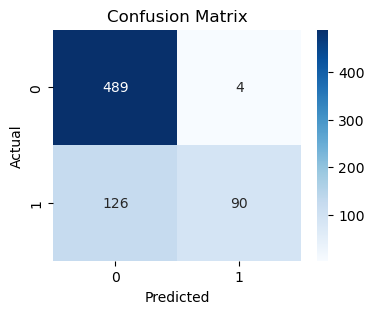

```
Train-Test Gap: 0.014
Test AUC Score: 0.682
```

```python
# Preparing X and y (make sure y is 0/1 already) --
X = pca_df
y = y_data

# Split
X_train, X_test, y_train, y_test = train_test_split(
    X,
    y,
    test_size=0.3,
    random_state=42,
    stratify=y
)

# Fit
model = LogisticRegression(max_iter=1000)
model.fit(X_train, y_train)

# Predict & evaluate
y_pred  = model.predict(X_test)
y_proba = model.predict_proba(X_test)[:,1]

print("AUC:     ", roc_auc_score(y_test, y_proba))
print("Accuracy:", accuracy_score(y_test, y_pred))

# Confusion matrix heatmap
cm = confusion_matrix(y_test, y_pred)
plt.figure(figsize=(4,3))
sns.heatmap(cm, annot=True, fmt="d", cmap="Blues")
plt.xlabel("Predicted")
plt.ylabel("Actual")
plt.title("Confusion Matrix")
plt.show()

# Predict probabilities
train_proba = model.predict_proba(X_train)[:, 1]
test_proba  = model.predict_proba(X_test)[:, 1]

# Compute AUCs
train_auc = roc_auc_score(y_train, train_proba)
test_auc  = roc_auc_score(y_test,  test_proba)

# Calculate gap
gap = abs(train_auc - test_auc)

# Print results
print(f"Train-Test Gap: {gap:.3f}")
print(f"Test AUC Score: {test_auc:.3f}")
```

```
AUC:      0.7468353241679815
Accuracy: 0.8166431593794076
```

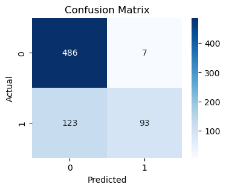

```
Train-Test Gap: 0.014
Test AUC Score: 0.747
```

```python
# Preparing X and y (make sure y is 0/1 already) --
X = pca_df_scaled
y = y_data

# Split
X_train, X_test, y_train, y_test = train_test_split(
    X,
    y,
    test_size=0.3,
    random_state=42,
    stratify=y
)

# Fit
model = LogisticRegression(max_iter=1000)
model.fit(X_train, y_train)

# Predict & evaluate
y_pred  = model.predict(X_test)
y_proba = model.predict_proba(X_test)[:,1]

print("AUC:     ", roc_auc_score(y_test, y_proba))
print("Accuracy:", accuracy_score(y_test, y_pred))

# Confusion matrix heatmap
cm = confusion_matrix(y_test, y_pred)
plt.figure(figsize=(4,3))
sns.heatmap(cm, annot=True, fmt="d", cmap="Blues")
plt.xlabel("Predicted")
plt.ylabel("Actual")
plt.title("Confusion Matrix")
plt.show()

# Predict probabilities
train_proba = model.predict_proba(X_train)[:, 1]
test_proba  = model.predict_proba(X_test)[:, 1]

# Compute AUCs
train_auc = roc_auc_score(y_train, train_proba)
test_auc  = roc_auc_score(y_test,  test_proba)

# Calculate gap
gap = abs(train_auc - test_auc)

# Print results
print(f"Train-Test Gap: {gap:.3f}")
print(f"Test AUC Score: {test_auc:.3f}")
```

# Best Model Selection and Rationale:

### Best Model: Model 1 (Original x-features)

**Rationale**:

Higher AUC: Model 1 has the **highest AUC score (0.79)**, indicating that it is the most effective model for distinguishing between video and non-video posts.

Lower False Negatives: The confusion matrix for Model 1 has fewer **false negatives (118**)**, indicating fewer video posts are missed compared to Models 2 and 3.

Interpretability: The original features (such as likes, shares, and comments) likely provide more intuitive and meaningful insights into the content type, whereas PCA and clustering reduce the data and may miss subtle patterns.

Consistency: Model 1 provides the most consistent results across both training and testing datasets, with a **minimal train-test gap (0.009)**, suggesting that the model generalizes well.

**Final Selection: Model 1 (Original x-features)** is the best choice for predicting whether a post is a video or not due to its higher AUC, accuracy, and better handling of false negatives compared to other models.

# Confusion Matrix Interpretation:

In Model 1 (Original x-features), the model correctly predicted **98 video posts (True Positives)**, while **8 non-video posts were incorrectly classified as videos (False Positives)**. There were **118 video posts mistakenly classified as non-videos (False Negatives)**, which is a key error since it could lead to missed opportunities for video promotion. The model also correctly predicted **485 non-video posts (True Negatives)**. The primary risk here is the **false negatives, as missing video content can lead to decreased engagement with video posts**.

# Final Model Selection:

Model 1 (Original x-features) is selected as the best model due to its **highest AUC score (0.79) and accuracy (82.2%)**, which indicates strong performance in distinguishing between video and non-video posts. It also has the **lowest false negatives (118)**, meaning fewer video posts are missed compared to Models 2 and 3. The model uses intuitive features like likes, comments, and shares, which make it easier to understand and interpret. Additionally, the **small train-test gap (0.009)** suggests the model generalizes well to unseen data, providing a good balance between performance and simplicity.

# Conclusion: